# Optimal Treatment Analysis

## Outcome Variable

**Outcome Variable:** ever_stunted

## Predictor Variables

**Intervention Variable:** hhwealth_quart

**Adjustment Set:**

- arm
- sex
- W_mage
- meducyrs
- feducyrs
- W_gagebrth
- W_birthwt
- W_birthlen
- W_nchldlt5
- W_parity
- delta_W_mage
- delta_meducyrs
- delta_feducyrs
- delta_W_gagebrth
- delta_W_birthwt
- delta_W_birthlen
- delta_W_nchldlt5
- delta_W_parity

## Stratifying Variables

The analysis was stratified on these variable(s):

- agecat
- studyid
- country

## Data Summary

| agecat | studyid | country | hhwealth_quart | ever_stunted | n_cell | n |
| --- | --- | --- | --- | --- | --- | --- |
| 0-24 months | ki0047075b-MAL-ED | BANGLADESH | Wealth Q4 | 0 | 7 | 82 |
| 0-24 months | ki0047075b-MAL-ED | BANGLADESH | Wealth Q4 | 1 | 14 | 82 |
| 0-24 months | ki0047075b-MAL-ED | BANGLADESH | Wealth Q1 | 0 | 6 | 82 |
| 0-24 months | ki0047075b-MAL-ED | BANGLADESH | Wealth Q1 | 1 | 15 | 82 |
| 0-24 months | ki0047075b-MAL-ED | BANGLADESH | Wealth Q2 | 0 | 8 | 82 |
| 0-24 months | ki0047075b-MAL-ED | BANGLADESH | Wealth Q2 | 1 | 12 | 82 |
| 0-24 months | ki0047075b-MAL-ED | BANGLADESH | Wealth Q3 | 0 | 8 | 82 |
| 0-24 months | ki0047075b-MAL-ED | BANGLADESH | Wealth Q3 | 1 | 12 | 82 |
| 0-24 months | ki0047075b-MAL-ED | INDIA | Wealth Q4 | 0 | 6 | 71 |
| 0-24 months | ki0047075b-MAL-ED | INDIA | Wealth Q4 | 1 | 12 | 71 |
| 0-24 months | ki0047075b-MAL-ED | INDIA | Wealth Q1 | 0 | 9 | 71 |
| 0-24 months | ki0047075b-MAL-ED | INDIA | Wealth Q1 | 1 | 10 | 71 |
| 0-24 months | ki0047075b-MAL-ED | INDIA | Wealth Q2 | 0 | 10 | 71 |
| 0-24 months | ki0047075b-MAL-ED | INDIA | Wealth Q2 | 1 | 7 | 71 |
| 0-24 months | ki0047075b-MAL-ED | INDIA | Wealth Q3 | 0 | 4 | 71 |
| 0-24 months | ki0047075b-MAL-ED | INDIA | Wealth Q3 | 1 | 13 | 71 |
| 0-24 months | ki0047075b-MAL-ED | NEPAL | Wealth Q4 | 0 | 4 | 42 |
| 0-24 months | ki0047075b-MAL-ED | NEPAL | Wealth Q4 | 1 | 7 | 42 |
| 0-24 months | ki0047075b-MAL-ED | NEPAL | Wealth Q1 | 0 | 6 | 42 |
| 0-24 months | ki0047075b-MAL-ED | NEPAL | Wealth Q1 | 1 | 5 | 42 |
| 0-24 months | ki0047075b-MAL-ED | NEPAL | Wealth Q2 | 0 | 4 | 42 |
| 0-24 months | ki0047075b-MAL-ED | NEPAL | Wealth Q2 | 1 | 6 | 42 |
| 0-24 months | ki0047075b-MAL-ED | NEPAL | Wealth Q3 | 0 | 6 | 42 |
| 0-24 months | ki0047075b-MAL-ED | NEPAL | Wealth Q3 | 1 | 4 | 42 |
| 0-24 months | ki0047075b-MAL-ED | PERU | Wealth Q4 | 0 | 2 | 37 |
| 0-24 months | ki0047075b-MAL-ED | PERU | Wealth Q4 | 1 | 8 | 37 |
| 0-24 months | ki0047075b-MAL-ED | PERU | Wealth Q1 | 0 | 2 | 37 |
| 0-24 months | ki0047075b-MAL-ED | PERU | Wealth Q1 | 1 | 7 | 37 |
| 0-24 months | ki0047075b-MAL-ED | PERU | Wealth Q2 | 0 | 0 | 37 |
| 0-24 months | ki0047075b-MAL-ED | PERU | Wealth Q2 | 1 | 9 | 37 |

[output cut: 378 more lines]

The following strata were considered:

- agecat: 0-24 months, studyid: ki0047075b-MAL-ED, country: BANGLADESH
- agecat: 0-24 months, studyid: ki0047075b-MAL-ED, country: INDIA
- agecat: 0-24 months, studyid: ki0047075b-MAL-ED, country: NEPAL
- agecat: 0-24 months, studyid: ki0047075b-MAL-ED, country: PERU
- agecat: 0-24 months, studyid: ki0047075b-MAL-ED, country: SOUTH AFRICA
- agecat: 0-24 months, studyid: ki0047075b-MAL-ED, country: TANZANIA, UNITED REPUBLIC OF
- agecat: 0-24 months, studyid: ki1000108-CMC-V-BCS-2002, country: INDIA
- agecat: 0-24 months, studyid: ki1000108-IRC, country: INDIA
- agecat: 0-24 months, studyid: ki1017093b-PROVIDE, country: BANGLADESH
- agecat: 0-24 months, studyid: ki1066203-TanzaniaChild2, country: TANZANIA, UNITED REPUBLIC OF
- agecat: 0-24 months, studyid: ki1113344-GMS-Nepal, country: NEPAL
- agecat: 0-24 months, studyid: ki1114097-CONTENT, country: PERU
- agecat: 0-24 months, studyid: ki1135781-COHORTS, country: GUATEMALA
- agecat: 0-24 months, studyid: ki1135781-COHORTS, country: PHILIPPINES
- agecat: 0-24 months, studyid: ki1148112-LCNI-5, country: MALAWI
- agecat: 0-24 months, studyid: kiGH5241-JiVitA-3, country: BANGLADESH
- agecat: 0-24 months, studyid: kiGH5241-JiVitA-4, country: BANGLADESH
- agecat: 0-6 months, studyid: ki0047075b-MAL-ED, country: BANGLADESH
- agecat: 0-6 months, studyid: ki0047075b-MAL-ED, country: INDIA
- agecat: 0-6 months, studyid: ki0047075b-MAL-ED, country: NEPAL
- agecat: 0-6 months, studyid: ki0047075b-MAL-ED, country: PERU
- agecat: 0-6 months, studyid: ki0047075b-MAL-ED, country: SOUTH AFRICA
- agecat: 0-6 months, studyid: ki0047075b-MAL-ED, country: TANZANIA, UNITED REPUBLIC OF
- agecat: 0-6 months, studyid: ki1000108-CMC-V-BCS-2002, country: INDIA
- agecat: 0-6 months, studyid: ki1000108-IRC, country: INDIA
- agecat: 0-6 months, studyid: ki1017093b-PROVIDE, country: BANGLADESH
- agecat: 0-6 months, studyid: ki1066203-TanzaniaChild2, country: TANZANIA, UNITED REPUBLIC OF
- agecat: 0-6 months, studyid: ki1113344-GMS-Nepal, country: NEPAL
- agecat: 0-6 months, studyid: ki1114097-CONTENT, country: PERU
- agecat: 0-6 months, studyid: ki1135781-COHORTS, country: GUATEMALA
- agecat: 0-6 months, studyid: ki1135781-COHORTS, country: PHILIPPINES
- agecat: 0-6 months, studyid: ki1148112-LCNI-5, country: MALAWI
- agecat: 0-6 months, studyid: kiGH5241-JiVitA-3, country: BANGLADESH
- agecat: 0-6 months, studyid: kiGH5241-JiVitA-4, country: BANGLADESH
- agecat: 6-24 months, studyid: ki0047075b-MAL-ED, country: BANGLADESH
- agecat: 6-24 months, studyid: ki0047075b-MAL-ED, country: INDIA
- agecat: 6-24 months, studyid: ki0047075b-MAL-ED, country: NEPAL
- agecat: 6-24 months, studyid: ki0047075b-MAL-ED, country: PERU
- agecat: 6-24 months, studyid: ki0047075b-MAL-ED, country: SOUTH AFRICA
- agecat: 6-24 months, studyid: ki0047075b-MAL-ED, country: TANZANIA, UNITED REPUBLIC OF
- agecat: 6-24 months, studyid: ki1000108-CMC-V-BCS-2002, country: INDIA
- agecat: 6-24 months, studyid: ki1000108-IRC, country: INDIA
- agecat: 6-24 months, studyid: ki1017093b-PROVIDE, country: BANGLADESH
- agecat: 6-24 months, studyid: ki1066203-TanzaniaChild2, country: TANZANIA, UNITED REPUBLIC OF
- agecat: 6-24 months, studyid: ki1113344-GMS-Nepal, country: NEPAL
- agecat: 6-24 months, studyid: ki1114097-CONTENT, country: PERU
- agecat: 6-24 months, studyid: ki1135781-COHORTS, country: GUATEMALA
- agecat: 6-24 months, studyid: ki1135781-COHORTS, country: PHILIPPINES
- agecat: 6-24 months, studyid: ki1148112-LCNI-5, country: MALAWI
- agecat: 6-24 months, studyid: kiGH5241-JiVitA-3, country: BANGLADESH
- agecat: 6-24 months, studyid: kiGH5241-JiVitA-4, country: BANGLADESH

### Dropped Strata

Some strata were dropped due to rare outcomes:

- agecat: 0-24 months, studyid: ki0047075b-MAL-ED, country: INDIA
- agecat: 0-24 months, studyid: ki0047075b-MAL-ED, country: NEPAL
- agecat: 0-24 months, studyid: ki0047075b-MAL-ED, country: PERU
- agecat: 0-24 months, studyid: ki0047075b-MAL-ED, country: TANZANIA, UNITED REPUBLIC OF
- agecat: 0-6 months, studyid: ki0047075b-MAL-ED, country: BANGLADESH
- agecat: 0-6 months, studyid: ki0047075b-MAL-ED, country: NEPAL
- agecat: 0-6 months, studyid: ki0047075b-MAL-ED, country: PERU
- agecat: 0-6 months, studyid: ki0047075b-MAL-ED, country: SOUTH AFRICA
- agecat: 0-6 months, studyid: ki0047075b-MAL-ED, country: TANZANIA, UNITED REPUBLIC OF
- agecat: 6-24 months, studyid: ki0047075b-MAL-ED, country: BANGLADESH
- agecat: 6-24 months, studyid: ki0047075b-MAL-ED, country: INDIA
- agecat: 6-24 months, studyid: ki0047075b-MAL-ED, country: NEPAL
- agecat: 6-24 months, studyid: ki0047075b-MAL-ED, country: PERU
- agecat: 6-24 months, studyid: ki0047075b-MAL-ED, country: SOUTH AFRICA
- agecat: 6-24 months, studyid: ki0047075b-MAL-ED, country: TANZANIA, UNITED REPUBLIC OF
- agecat: 6-24 months, studyid: ki1114097-CONTENT, country: PERU

## Methods Detail

We’re interested in the causal parameters $E[Y_a]$ for all values of $a \in \mathcal{A}$. These parameters represent the mean outcome if, possibly contrary to fact, we intervened to set all units to have $A=a$. Under the randomization and positivity assumptions, these are identified by the statistical parameters $\psi_a=E_W[E_{Y|A,W}(Y|A=a,W)]$. In addition, we’re interested in the mean of $Y$, $E[Y]$ under no intervention (the observed mean). We will estimate these parameters by using SuperLearner to fit the relevant likelihood factors – $E_{Y|A,W}(Y|A=a,W)$ and $p(A=a|W)$, and then updating our likelihood fit using a joint TMLE.

For unadjusted analyses ($W=\{\}$), initial likelihoods were estimated using Lrnr_glm to estimate the simple $E(Y|A)$ and Lrnr_mean to estimate $p(A)$. For adjusted analyses, a small library containing Lrnr_glmnet, Lrnr_xgboost, and Lrnr_mean was used.

Having estimated these parameters, we will then use the delta method to estimate relative risks and attributable risks relative to a prespecified baseline level of $A$.

# Results Detail

## Results Plots

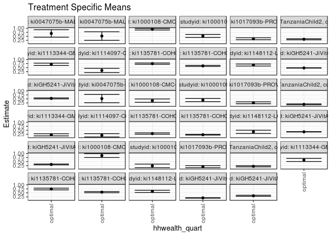

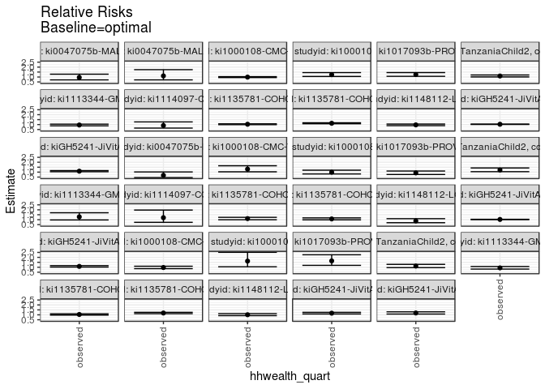

## Results Table

### Parameter: TSM

| agecat | studyid | country | intervention_level | baseline_level | estimate | ci_lower | ci_upper |
| --- | --- | --- | --- | --- | --- | --- | --- |
| 0-24 months | ki0047075b-MAL-ED | BANGLADESH | optimal | NA | 0.6775661 | 0.4452843 | 0.9098479 |
| 0-24 months | ki0047075b-MAL-ED | SOUTH AFRICA | optimal | NA | 0.5160365 | 0.2488360 | 0.7832369 |
| 0-24 months | ki1000108-CMC-V-BCS-2002 | INDIA | optimal | NA | 0.9359203 | 0.8891590 | 0.9826815 |
| 0-24 months | ki1000108-IRC | INDIA | optimal | NA | 0.5193060 | 0.4241892 | 0.6144227 |
| 0-24 months | ki1017093b-PROVIDE | BANGLADESH | optimal | NA | 0.3485680 | 0.2872084 | 0.4099276 |
| 0-24 months | ki1066203-TanzaniaChild2 | TANZANIA, UNITED REPUBLIC OF | optimal | NA | 0.3153262 | 0.2820191 | 0.3486334 |
| 0-24 months | ki1113344-GMS-Nepal | NEPAL | optimal | NA | 0.7059910 | 0.6340255 | 0.7779565 |
| 0-24 months | ki1114097-CONTENT | PERU | optimal | NA | 0.3243009 | 0.1921782 | 0.4564237 |
| 0-24 months | ki1135781-COHORTS | GUATEMALA | optimal | NA | 0.7468160 | 0.7060560 | 0.7875760 |
| 0-24 months | ki1135781-COHORTS | PHILIPPINES | optimal | NA | 0.6071483 | 0.5758681 | 0.6384284 |
| 0-24 months | ki1148112-LCNI-5 | MALAWI | optimal | NA | 0.6592760 | 0.5966503 | 0.7219017 |
| 0-24 months | kiGH5241-JiVitA-3 | BANGLADESH | optimal | NA | 0.4791812 | 0.4679194 | 0.4904430 |
| 0-24 months | kiGH5241-JiVitA-4 | BANGLADESH | optimal | NA | 0.5309527 | 0.4997589 | 0.5621465 |
| 0-6 months | ki0047075b-MAL-ED | INDIA | optimal | NA | 0.5212342 | 0.2627879 | 0.7796805 |
| 0-6 months | ki1000108-CMC-V-BCS-2002 | INDIA | optimal | NA | 0.3922269 | 0.2889169 | 0.4955369 |
| 0-6 months | ki1000108-IRC | INDIA | optimal | NA | 0.4291625 | 0.3314296 | 0.5268953 |
| 0-6 months | ki1017093b-PROVIDE | BANGLADESH | optimal | NA | 0.2599178 | 0.1999656 | 0.3198700 |
| 0-6 months | ki1066203-TanzaniaChild2 | TANZANIA, UNITED REPUBLIC OF | optimal | NA | 0.1601160 | 0.1320221 | 0.1882100 |
| 0-6 months | ki1113344-GMS-Nepal | NEPAL | optimal | NA | 0.2155305 | 0.1476426 | 0.2834185 |
| 0-6 months | ki1114097-CONTENT | PERU | optimal | NA | 0.1855337 | 0.0802112 | 0.2908562 |
| 0-6 months | ki1135781-COHORTS | GUATEMALA | optimal | NA | 0.2923468 | 0.2499051 | 0.3347884 |
| 0-6 months | ki1135781-COHORTS | PHILIPPINES | optimal | NA | 0.2216876 | 0.1971706 | 0.2462046 |
| 0-6 months | ki1148112-LCNI-5 | MALAWI | optimal | NA | 0.4028072 | 0.2999510 | 0.5056634 |
| 0-6 months | kiGH5241-JiVitA-3 | BANGLADESH | optimal | NA | 0.4007470 | 0.3903066 | 0.4111875 |
| 0-6 months | kiGH5241-JiVitA-4 | BANGLADESH | optimal | NA | 0.3194502 | 0.2927001 | 0.3462003 |
| 6-24 months | ki1000108-CMC-V-BCS-2002 | INDIA | optimal | NA | 0.8713116 | 0.7517521 | 0.9908712 |
| 6-24 months | ki1000108-IRC | INDIA | optimal | NA | 0.2321483 | 0.1205427 | 0.3437538 |
| 6-24 months | ki1017093b-PROVIDE | BANGLADESH | optimal | NA | 0.1818951 | 0.1171453 | 0.2466449 |
| 6-24 months | ki1066203-TanzaniaChild2 | TANZANIA, UNITED REPUBLIC OF | optimal | NA | 0.2030496 | 0.1677485 | 0.2383508 |
| 6-24 months | ki1113344-GMS-Nepal | NEPAL | optimal | NA | 0.5988348 | 0.5027178 | 0.6949518 |
| 6-24 months | ki1135781-COHORTS | GUATEMALA | optimal | NA | 0.7404058 | 0.6852418 | 0.7955699 |
| 6-24 months | ki1135781-COHORTS | PHILIPPINES | optimal | NA | 0.5450319 | 0.5067851 | 0.5832788 |
| 6-24 months | ki1148112-LCNI-5 | MALAWI | optimal | NA | 0.5933246 | 0.5233571 | 0.6632920 |
| 6-24 months | kiGH5241-JiVitA-3 | BANGLADESH | optimal | NA | 0.1862143 | 0.1709001 | 0.2015285 |
| 6-24 months | kiGH5241-JiVitA-4 | BANGLADESH | optimal | NA | 0.3189457 | 0.2842974 | 0.3535940 |

### Parameter: E(Y)

| agecat | studyid | country | intervention_level | baseline_level | estimate | ci_lower | ci_upper |
| --- | --- | --- | --- | --- | --- | --- | --- |
| 0-24 months | ki0047075b-MAL-ED | BANGLADESH | observed | NA | 0.6463415 | 0.5422228 | 0.7504601 |
| 0-24 months | ki0047075b-MAL-ED | SOUTH AFRICA | observed | NA | 0.5735294 | 0.4551072 | 0.6919516 |
| 0-24 months | ki1000108-CMC-V-BCS-2002 | INDIA | observed | NA | 0.9249330 | 0.8981563 | 0.9517096 |
| 0-24 months | ki1000108-IRC | INDIA | observed | NA | 0.6414634 | 0.5949863 | 0.6879405 |
| 0-24 months | ki1017093b-PROVIDE | BANGLADESH | observed | NA | 0.4340974 | 0.3973018 | 0.4708930 |
| 0-24 months | ki1066203-TanzaniaChild2 | TANZANIA, UNITED REPUBLIC OF | observed | NA | 0.3468960 | 0.3277853 | 0.3660067 |
| 0-24 months | ki1113344-GMS-Nepal | NEPAL | observed | NA | 0.6744186 | 0.6369554 | 0.7118819 |
| 0-24 months | ki1114097-CONTENT | PERU | observed | NA | 0.2930233 | 0.2320422 | 0.3540043 |
| 0-24 months | ki1135781-COHORTS | GUATEMALA | observed | NA | 0.7715180 | 0.7484902 | 0.7945458 |
| 0-24 months | ki1135781-COHORTS | PHILIPPINES | observed | NA | 0.6866209 | 0.6701747 | 0.7030670 |
| 0-24 months | ki1148112-LCNI-5 | MALAWI | observed | NA | 0.6376989 | 0.6047193 | 0.6706785 |
| 0-24 months | kiGH5241-JiVitA-3 | BANGLADESH | observed | NA | 0.4938998 | 0.4860534 | 0.5017461 |
| 0-24 months | kiGH5241-JiVitA-4 | BANGLADESH | observed | NA | 0.5818282 | 0.5658219 | 0.5978346 |
| 0-6 months | ki0047075b-MAL-ED | INDIA | observed | NA | 0.3521127 | 0.2402231 | 0.4640023 |
| 0-6 months | ki1000108-CMC-V-BCS-2002 | INDIA | observed | NA | 0.5108696 | 0.4597270 | 0.5620121 |
| 0-6 months | ki1000108-IRC | INDIA | observed | NA | 0.4243902 | 0.3764905 | 0.4722900 |
| 0-6 months | ki1017093b-PROVIDE | BANGLADESH | observed | NA | 0.2392550 | 0.2075826 | 0.2709275 |
| 0-6 months | ki1066203-TanzaniaChild2 | TANZANIA, UNITED REPUBLIC OF | observed | NA | 0.1950503 | 0.1791413 | 0.2109594 |
| 0-6 months | ki1113344-GMS-Nepal | NEPAL | observed | NA | 0.2774086 | 0.2416141 | 0.3132032 |
| 0-6 months | ki1114097-CONTENT | PERU | observed | NA | 0.2232558 | 0.1674626 | 0.2790491 |
| 0-6 months | ki1135781-COHORTS | GUATEMALA | observed | NA | 0.3240116 | 0.2955133 | 0.3525098 |
| 0-6 months | ki1135781-COHORTS | PHILIPPINES | observed | NA | 0.2391233 | 0.2240003 | 0.2542464 |
| 0-6 months | ki1148112-LCNI-5 | MALAWI | observed | NA | 0.3531599 | 0.2959376 | 0.4103821 |
| 0-6 months | kiGH5241-JiVitA-3 | BANGLADESH | observed | NA | 0.4108893 | 0.4034376 | 0.4183410 |
| 0-6 months | kiGH5241-JiVitA-4 | BANGLADESH | observed | NA | 0.3474692 | 0.3322601 | 0.3626783 |
| 6-24 months | ki1000108-CMC-V-BCS-2002 | INDIA | observed | NA | 0.8486486 | 0.7968646 | 0.9004327 |
| 6-24 months | ki1000108-IRC | INDIA | observed | NA | 0.3771186 | 0.3151523 | 0.4390850 |
| 6-24 months | ki1017093b-PROVIDE | BANGLADESH | observed | NA | 0.2989011 | 0.2567922 | 0.3410100 |
| 6-24 months | ki1066203-TanzaniaChild2 | TANZANIA, UNITED REPUBLIC OF | observed | NA | 0.2268170 | 0.2062654 | 0.2473687 |
| 6-24 months | ki1113344-GMS-Nepal | NEPAL | observed | NA | 0.5610329 | 0.5138522 | 0.6082135 |
| 6-24 months | ki1135781-COHORTS | GUATEMALA | observed | NA | 0.7665094 | 0.7380190 | 0.7949999 |
| 6-24 months | ki1135781-COHORTS | PHILIPPINES | observed | NA | 0.6449788 | 0.6246093 | 0.6653483 |
| 6-24 months | ki1148112-LCNI-5 | MALAWI | observed | NA | 0.6000000 | 0.5639396 | 0.6360604 |
| 6-24 months | kiGH5241-JiVitA-3 | BANGLADESH | observed | NA | 0.2172797 | 0.2079084 | 0.2266510 |
| 6-24 months | kiGH5241-JiVitA-4 | BANGLADESH | observed | NA | 0.3784303 | 0.3598372 | 0.3970234 |

### Parameter: RR

| agecat | studyid | country | intervention_level | baseline_level | estimate | ci_lower | ci_upper |
| --- | --- | --- | --- | --- | --- | --- | --- |
| 0-24 months | ki0047075b-MAL-ED | BANGLADESH | observed | optimal | 0.9539164 | 0.7083704 | 1.284577 |
| 0-24 months | ki0047075b-MAL-ED | SOUTH AFRICA | observed | optimal | 1.1114126 | 0.7100809 | 1.739574 |
| 0-24 months | ki1000108-CMC-V-BCS-2002 | INDIA | observed | optimal | 0.9882604 | 0.9439428 | 1.034659 |
| 0-24 months | ki1000108-IRC | INDIA | observed | optimal | 1.2352321 | 1.0552022 | 1.445977 |
| 0-24 months | ki1017093b-PROVIDE | BANGLADESH | observed | optimal | 1.2453736 | 1.0701139 | 1.449337 |
| 0-24 months | ki1066203-TanzaniaChild2 | TANZANIA, UNITED REPUBLIC OF | observed | optimal | 1.1001177 | 1.0065773 | 1.202351 |
| 0-24 months | ki1113344-GMS-Nepal | NEPAL | observed | optimal | 0.9552793 | 0.8732037 | 1.045069 |
| 0-24 months | ki1114097-CONTENT | PERU | observed | optimal | 0.9035535 | 0.6441382 | 1.267444 |
| 0-24 months | ki1135781-COHORTS | GUATEMALA | observed | optimal | 1.0330765 | 0.9899543 | 1.078077 |
| 0-24 months | ki1135781-COHORTS | PHILIPPINES | observed | optimal | 1.1308949 | 1.0841678 | 1.179636 |
| 0-24 months | ki1148112-LCNI-5 | MALAWI | observed | optimal | 0.9672715 | 0.8896402 | 1.051677 |
| 0-24 months | kiGH5241-JiVitA-3 | BANGLADESH | observed | optimal | 1.0307161 | 1.0134275 | 1.048300 |
| 0-24 months | kiGH5241-JiVitA-4 | BANGLADESH | observed | optimal | 1.0958194 | 1.0422907 | 1.152097 |
| 0-6 months | ki0047075b-MAL-ED | INDIA | observed | optimal | 0.6755364 | 0.4480738 | 1.018469 |
| 0-6 months | ki1000108-CMC-V-BCS-2002 | INDIA | observed | optimal | 1.3024848 | 1.0318874 | 1.644042 |
| 0-6 months | ki1000108-IRC | INDIA | observed | optimal | 0.9888802 | 0.8170900 | 1.196789 |
| 0-6 months | ki1017093b-PROVIDE | BANGLADESH | observed | optimal | 0.9205025 | 0.7628776 | 1.110696 |
| 0-6 months | ki1066203-TanzaniaChild2 | TANZANIA, UNITED REPUBLIC OF | observed | optimal | 1.2181811 | 1.0449455 | 1.420136 |
| 0-6 months | ki1113344-GMS-Nepal | NEPAL | observed | optimal | 1.2870967 | 0.9740118 | 1.700819 |
| 0-6 months | ki1114097-CONTENT | PERU | observed | optimal | 1.2033169 | 0.7336308 | 1.973706 |
| 0-6 months | ki1135781-COHORTS | GUATEMALA | observed | optimal | 1.1083125 | 0.9919515 | 1.238323 |
| 0-6 months | ki1135781-COHORTS | PHILIPPINES | observed | optimal | 1.0786499 | 0.9851306 | 1.181047 |
| 0-6 months | ki1148112-LCNI-5 | MALAWI | observed | optimal | 0.8767467 | 0.6966517 | 1.103399 |
| 0-6 months | kiGH5241-JiVitA-3 | BANGLADESH | observed | optimal | 1.0253083 | 1.0071463 | 1.043798 |
| 0-6 months | kiGH5241-JiVitA-4 | BANGLADESH | observed | optimal | 1.0877101 | 1.0164633 | 1.163951 |
| 6-24 months | ki1000108-CMC-V-BCS-2002 | INDIA | observed | optimal | 0.9739898 | 0.8577790 | 1.105945 |
| 6-24 months | ki1000108-IRC | INDIA | observed | optimal | 1.6244733 | 1.0509470 | 2.510986 |
| 6-24 months | ki1017093b-PROVIDE | BANGLADESH | observed | optimal | 1.6432609 | 1.1935780 | 2.262363 |
| 6-24 months | ki1066203-TanzaniaChild2 | TANZANIA, UNITED REPUBLIC OF | observed | optimal | 1.1170522 | 0.9645056 | 1.293726 |
| 6-24 months | ki1113344-GMS-Nepal | NEPAL | observed | optimal | 0.9368742 | 0.8156972 | 1.076053 |
| 6-24 months | ki1135781-COHORTS | GUATEMALA | observed | optimal | 1.0352558 | 0.9737383 | 1.100660 |
| 6-24 months | ki1135781-COHORTS | PHILIPPINES | observed | optimal | 1.1833779 | 1.1168942 | 1.253819 |
| 6-24 months | ki1148112-LCNI-5 | MALAWI | observed | optimal | 1.0112509 | 0.9143318 | 1.118443 |
| 6-24 months | kiGH5241-JiVitA-3 | BANGLADESH | observed | optimal | 1.1668262 | 1.0882364 | 1.251092 |
| 6-24 months | kiGH5241-JiVitA-4 | BANGLADESH | observed | optimal | 1.1865039 | 1.0785726 | 1.305236 |

### Parameter: PAR

| agecat | studyid | country | intervention_level | baseline_level | estimate | ci_lower | ci_upper |
| --- | --- | --- | --- | --- | --- | --- | --- |
| 0-24 months | ki0047075b-MAL-ED | BANGLADESH | optimal | NA | -0.0312247 | -0.2330945 | 0.1706452 |
| 0-24 months | ki0047075b-MAL-ED | SOUTH AFRICA | optimal | NA | 0.0574930 | -0.1724077 | 0.2873937 |
| 0-24 months | ki1000108-CMC-V-BCS-2002 | INDIA | optimal | NA | -0.0109873 | -0.0538756 | 0.0319011 |
| 0-24 months | ki1000108-IRC | INDIA | optimal | NA | 0.1221575 | 0.0412296 | 0.2030853 |
| 0-24 months | ki1017093b-PROVIDE | BANGLADESH | optimal | NA | 0.0855294 | 0.0323908 | 0.1386680 |
| 0-24 months | ki1066203-TanzaniaChild2 | TANZANIA, UNITED REPUBLIC OF | optimal | NA | 0.0315697 | 0.0035356 | 0.0596039 |
| 0-24 months | ki1113344-GMS-Nepal | NEPAL | optimal | NA | -0.0315724 | -0.0948847 | 0.0317399 |
| 0-24 months | ki1114097-CONTENT | PERU | optimal | NA | -0.0312777 | -0.1415961 | 0.0790407 |
| 0-24 months | ki1135781-COHORTS | GUATEMALA | optimal | NA | 0.0247020 | -0.0070708 | 0.0564748 |
| 0-24 months | ki1135781-COHORTS | PHILIPPINES | optimal | NA | 0.0794726 | 0.0540658 | 0.1048794 |
| 0-24 months | ki1148112-LCNI-5 | MALAWI | optimal | NA | -0.0215771 | -0.0766609 | 0.0335067 |
| 0-24 months | kiGH5241-JiVitA-3 | BANGLADESH | optimal | NA | 0.0147186 | 0.0066156 | 0.0228216 |
| 0-24 months | kiGH5241-JiVitA-4 | BANGLADESH | optimal | NA | 0.0508755 | 0.0243427 | 0.0774084 |
| 0-6 months | ki0047075b-MAL-ED | INDIA | optimal | NA | -0.1691215 | -0.3849777 | 0.0467348 |
| 0-6 months | ki1000108-CMC-V-BCS-2002 | INDIA | optimal | NA | 0.1186427 | 0.0278326 | 0.2094528 |
| 0-6 months | ki1000108-IRC | INDIA | optimal | NA | -0.0047722 | -0.0867023 | 0.0771578 |
| 0-6 months | ki1017093b-PROVIDE | BANGLADESH | optimal | NA | -0.0206628 | -0.0695798 | 0.0282541 |
| 0-6 months | ki1066203-TanzaniaChild2 | TANZANIA, UNITED REPUBLIC OF | optimal | NA | 0.0349343 | 0.0102771 | 0.0595915 |
| 0-6 months | ki1113344-GMS-Nepal | NEPAL | optimal | NA | 0.0618781 | 0.0018161 | 0.1219401 |
| 0-6 months | ki1114097-CONTENT | PERU | optimal | NA | 0.0377221 | -0.0540002 | 0.1294444 |
| 0-6 months | ki1135781-COHORTS | GUATEMALA | optimal | NA | 0.0316648 | -0.0007338 | 0.0640634 |
| 0-6 months | ki1135781-COHORTS | PHILIPPINES | optimal | NA | 0.0174357 | -0.0026990 | 0.0375705 |
| 0-6 months | ki1148112-LCNI-5 | MALAWI | optimal | NA | -0.0496473 | -0.1411051 | 0.0418105 |
| 0-6 months | kiGH5241-JiVitA-3 | BANGLADESH | optimal | NA | 0.0101422 | 0.0029862 | 0.0172983 |
| 0-6 months | kiGH5241-JiVitA-4 | BANGLADESH | optimal | NA | 0.0280190 | 0.0064479 | 0.0495902 |
| 6-24 months | ki1000108-CMC-V-BCS-2002 | INDIA | optimal | NA | -0.0226630 | -0.1332830 | 0.0879571 |
| 6-24 months | ki1000108-IRC | INDIA | optimal | NA | 0.1449704 | 0.0434744 | 0.2464664 |
| 6-24 months | ki1017093b-PROVIDE | BANGLADESH | optimal | NA | 0.1170060 | 0.0573816 | 0.1766304 |
| 6-24 months | ki1066203-TanzaniaChild2 | TANZANIA, UNITED REPUBLIC OF | optimal | NA | 0.0237674 | -0.0060878 | 0.0536226 |
| 6-24 months | ki1113344-GMS-Nepal | NEPAL | optimal | NA | -0.0378019 | -0.1207376 | 0.0451338 |
| 6-24 months | ki1135781-COHORTS | GUATEMALA | optimal | NA | 0.0261036 | -0.0191762 | 0.0713834 |
| 6-24 months | ki1135781-COHORTS | PHILIPPINES | optimal | NA | 0.0999468 | 0.0687807 | 0.1311130 |
| 6-24 months | ki1148112-LCNI-5 | MALAWI | optimal | NA | 0.0066754 | -0.0530985 | 0.0664494 |
| 6-24 months | kiGH5241-JiVitA-3 | BANGLADESH | optimal | NA | 0.0310654 | 0.0180210 | 0.0441098 |
| 6-24 months | kiGH5241-JiVitA-4 | BANGLADESH | optimal | NA | 0.0594846 | 0.0290165 | 0.0899527 |

### Parameter: PAF

| agecat | studyid | country | intervention_level | baseline_level | estimate | ci_lower | ci_upper |
| --- | --- | --- | --- | --- | --- | --- | --- |
| 0-24 months | ki0047075b-MAL-ED | BANGLADESH | optimal | NA | -0.0483099 | -0.4116908 | 0.2215338 |
| 0-24 months | ki0047075b-MAL-ED | SOUTH AFRICA | optimal | NA | 0.1002441 | -0.4082903 | 0.4251465 |
| 0-24 months | ki1000108-CMC-V-BCS-2002 | INDIA | optimal | NA | -0.0118790 | -0.0593863 | 0.0334978 |
| 0-24 months | ki1000108-IRC | INDIA | optimal | NA | 0.1904356 | 0.0523143 | 0.3084262 |
| 0-24 months | ki1017093b-PROVIDE | BANGLADESH | optimal | NA | 0.1970281 | 0.0655200 | 0.3100292 |
| 0-24 months | ki1066203-TanzaniaChild2 | TANZANIA, UNITED REPUBLIC OF | optimal | NA | 0.0910064 | 0.0065343 | 0.1682959 |
| 0-24 months | ki1113344-GMS-Nepal | NEPAL | optimal | NA | -0.0468143 | -0.1452081 | 0.0431258 |
| 0-24 months | ki1114097-CONTENT | PERU | optimal | NA | -0.1067413 | -0.5524618 | 0.2110104 |
| 0-24 months | ki1135781-COHORTS | GUATEMALA | optimal | NA | 0.0320174 | -0.0101477 | 0.0724225 |
| 0-24 months | ki1135781-COHORTS | PHILIPPINES | optimal | NA | 0.1157445 | 0.0776336 | 0.1522807 |
| 0-24 months | ki1148112-LCNI-5 | MALAWI | optimal | NA | -0.0338359 | -0.1240499 | 0.0491378 |
| 0-24 months | kiGH5241-JiVitA-3 | BANGLADESH | optimal | NA | 0.0298008 | 0.0132496 | 0.0460744 |
| 0-24 months | kiGH5241-JiVitA-4 | BANGLADESH | optimal | NA | 0.0874408 | 0.0405748 | 0.1320176 |
| 0-6 months | ki0047075b-MAL-ED | INDIA | optimal | NA | -0.4803050 | -1.2317750 | 0.0181345 |
| 0-6 months | ki1000108-CMC-V-BCS-2002 | INDIA | optimal | NA | 0.2322367 | 0.0309020 | 0.3917432 |
| 0-6 months | ki1000108-IRC | INDIA | optimal | NA | -0.0112449 | -0.2238553 | 0.1644305 |
| 0-6 months | ki1017093b-PROVIDE | BANGLADESH | optimal | NA | -0.0863632 | -0.3108262 | 0.0996633 |
| 0-6 months | ki1066203-TanzaniaChild2 | TANZANIA, UNITED REPUBLIC OF | optimal | NA | 0.1791040 | 0.0430123 | 0.2958422 |
| 0-6 months | ki1113344-GMS-Nepal | NEPAL | optimal | NA | 0.2230576 | -0.0266816 | 0.4120480 |
| 0-6 months | ki1114097-CONTENT | PERU | optimal | NA | 0.1689637 | -0.3630834 | 0.4933389 |
| 0-6 months | ki1135781-COHORTS | GUATEMALA | optimal | NA | 0.0977274 | -0.0081138 | 0.1924564 |
| 0-6 months | ki1135781-COHORTS | PHILIPPINES | optimal | NA | 0.0729151 | -0.0150938 | 0.1532937 |
| 0-6 months | ki1148112-LCNI-5 | MALAWI | optimal | NA | -0.1405803 | -0.4354376 | 0.0937095 |
| 0-6 months | kiGH5241-JiVitA-3 | BANGLADESH | optimal | NA | 0.0246836 | 0.0070956 | 0.0419600 |
| 0-6 months | kiGH5241-JiVitA-4 | BANGLADESH | optimal | NA | 0.0806374 | 0.0161966 | 0.1408572 |
| 6-24 months | ki1000108-CMC-V-BCS-2002 | INDIA | optimal | NA | -0.0267048 | -0.1658015 | 0.0957957 |
| 6-24 months | ki1000108-IRC | INDIA | optimal | NA | 0.3844159 | 0.0484772 | 0.6017501 |
| 6-24 months | ki1017093b-PROVIDE | BANGLADESH | optimal | NA | 0.3914539 | 0.1621829 | 0.5579842 |
| 6-24 months | ki1066203-TanzaniaChild2 | TANZANIA, UNITED REPUBLIC OF | optimal | NA | 0.1047867 | -0.0368006 | 0.2270386 |
| 6-24 months | ki1113344-GMS-Nepal | NEPAL | optimal | NA | -0.0673791 | -0.2259451 | 0.0706777 |
| 6-24 months | ki1135781-COHORTS | GUATEMALA | optimal | NA | 0.0340552 | -0.0269700 | 0.0914541 |
| 6-24 months | ki1135781-COHORTS | PHILIPPINES | optimal | NA | 0.1549614 | 0.1046600 | 0.2024368 |
| 6-24 months | ki1148112-LCNI-5 | MALAWI | optimal | NA | 0.0111257 | -0.0936949 | 0.1059003 |
| 6-24 months | kiGH5241-JiVitA-3 | BANGLADESH | optimal | NA | 0.1429744 | 0.0810820 | 0.2006981 |
| 6-24 months | kiGH5241-JiVitA-4 | BANGLADESH | optimal | NA | 0.1571877 | 0.0728487 | 0.2338548 |